# Inferential Statistics

##### Libraries

```r
# ============================
# Data Manipulation / Databases
# ============================
library(tidyverse)   # Collection of packages for data manipulation (dplyr, tidyr) and visualization (ggplot2)
library(dplyr)       # Data manipulation: filtering, summarizing, joining
library(plyr)        # Older data manipulation package (mostly superseded by dplyr)
library(dbplyr)      # Interface to translate dplyr syntax to SQL for databases

# ============================
# Descriptive Statistics & Visualization
# ============================
library(ggplot2)     # Flexible and powerful plotting system
library(ggpubr)      # Easy-to-use publication-ready plots with ggplot2 enhancements
library(lattice)     # Alternative plotting system for multi-panel plots
library(descr)       # Descriptive statistics: frequency tables, crosstabs
library(Rmisc)       # Utility functions for summaries: mean, SE, CI
library(knitr)       # Dynamic report generation, integration with R Markdown
library(kableExtra)  # Enhanced tables for knitr and R Markdown
```

##### Import Data

```r
dataseniors<-read.csv2("seniors2.csv", sep=";", dec=",")#read data
data.df<-data.frame(dataseniors[1:310,1:31])#data frame(rectangular data structures)
```

## Inference Analysis

- we want to estimate the parameters of a population without being able to observe the population
- **Statistic** is a mathematical function of the elements in the sample with a known distribution function
- **Estimator** is a parameter (statistic) that can be used to estimate the population parameters. only some of the sample parameters are estimators

X ∼ FX (μX , σX)

X is the random variable under analysis

Fx is distribution function with parameters μX (population mean) and σX (population standard deviation)

## Estimators

unbiased **estimators** are those with expected value equal to the true population parameter

- for this class, the mean and proportion are both unbiased estimators
- the best or most efficient estimators are those with minimal variance
- the average of several sample means is equal to the population mean

### Point Estimates

A **point estimate** is a single, specific value that is the best guess for an unknown population parameter, calculated from a sample.

- However, a point estimate does not account for all the variability for all the possible samples
- We need to consider all the possible variability, and consider the confidence intervals

### How to Create a Sample from an Existing Population

```r
set.seed(1)
sample1 <-
  rnorm(n=50, mean=5.44, sd=2)
sample2 <-
  rnorm(n=75, mean=5.44, sd=2)
sample3 <-
  rnorm(n=60, mean=5.44, sd=2)
sample4 <-
  rnorm(n=100, mean=5.44, sd=2)
sample5 <-
  rnorm(n=150, mean=5.44, sd=2)
CI_m(sample1, ci=0.50)
CI_m(sample2, ci=0.50)
CI_m(sample3, ci=0.50)
CI_m(sample4, ci=0.50)
CI_m(sample5, ci=0.50)
```

[output not shown]

## Confidence Intervals

Instead of providing a single point estimate for the population parameter, we provide a range of plausible values that accounts for sampling variability

- CI(parameter) = point estimate ∓ quantile of estimator x standard deviation of estimator
  - CI(μX)(1-α)% = x̄ ∓ zα / 2 * σX / √n
- we must assume or know the distribution of the estimator (normal distribution)
- take a simple random sample of size n from the population
- choose a confidence level 1 - α (alpha, related to the quantile of estimator)
- Determine the α/2 and 1 − α/2 quantiles of the estimator’s distribution
- written as CI95% = (lower bound [LB], upper bound [UB])
- we are (1 - α)100% confident that the actual parameter will be inside the CI(1-α)100%
- a large sample size (n > 30) is needed to accurately calculate the confidence interval

### Confidence interval for the population mean (unknown variance)

```r
CI_m <- function (x, ci = 0.95)
{
  standard_deviation <- sd(x)
  sample_size <- length(x)
  Margin_Error <- abs(qt((1-ci)/2,df=sample_size-1))* standard_deviation/sqrt(sample_size)
df_out <-
  data.frame(
    sample_size=length(x),
    Mean=mean(x), sd=sd(x),
    Margin_Error=Margin_Error,
    'CI lower limit'=(mean(x) - Margin_Error),
    'CI Upper limit'=(mean(x) + Margin_Error)) |>
    tidyr::pivot_longer(
      names_to = "Measurements",
      values_to ="values", 1:6
      )
  return(df_out)
}
# Example. Compute 95% confidence interval for the mean of 'Value' in the population
CI_m(data.df$value, ci=0.95)
```

```
# A tibble: 6 × 2
  Measurements    values
  <chr>            <dbl>
1 sample_size    310
2 Mean             4.55
3 sd               1.19
4 Margin_Error     0.133
5 CI.lower.limit   4.42
6 CI.Upper.limit   4.68
```

### Confidence interval for the population proportion in a Bernoulli distribution

```r
CI_p <- function(x, ci = 95)
{
  vcat<-na.omit(x)
  p <- mean(x)
  standard_deviation <- sqrt(p*(1-p))
  sample_size <- length(x)
  Margin_Error <- abs(qnorm((1-ci)/2))* standard_deviation/sqrt(sample_size)
  df_out <-
    data.frame(
      sample_size=length(x),
      p,
      Margin_Error=Margin_Error,
      'CI lower limit'=(p - Margin_Error),
      'CI Upper limit'=(p + Margin_Error)) |>
    tidyr::pivot_longer(
      names_to = "Measurements",
      values_to ="values", 1:5
      )
  return(df_out)
}
```

### Example Confidence Interval

```r
prop <- ifelse(data.df$value > 5, 1, 0) #Generate the Bernoulli sample with 1(meet the condition) and 0
prop.table(table(prop))
```

```
prop
        0         1
0.6419355 0.3580645
```

```r
CI_p(prop ,ci=0.95)
```

```
# A tibble: 5 × 2
  Measurements     values
  <chr>             <dbl>
1 sample_size    310
2 p                0.358
3 Margin_Error     0.0534
4 CI.lower.limit   0.305
5 CI.Upper.limit   0.411
```

### Plot 95% confidence intervals divided by one variable

Function “summarySE” in the library Rmisc allow us to summarise one variable divided in groups.

```r
df <- summarySE(data.df, measurevar="value", groupvars="gender", na.rm=T)

graf.point1 <- ggplot(df, aes(x=gender, y=value)) +
  geom_point(size = 3) + ylim(3, 5) +
  geom_errorbar(aes(ymin=value-ci, ymax=value+ci), width = 0.2) +
  ylab("Importance") +
  ggtitle("95% Confidence interval for the mean importance of Value by gender")
graf.point1
```

[figure not shown]

### Plot 95% confidence intervals divided by two variables

```r
df <- summarySE(data.df, measurevar="value", groupvars=c("gender","age"), na.rm=T)

graf.point2 <- ggplot(df, aes(x=age, y=value, colour=gender)) +
  geom_point(size = 3) +
  ylim(3, 5.5) +
  geom_errorbar(aes(ymin=value-ci, ymax=value+ci), width = 0.2) +
  ylab("Importance") +
  ggtitle("95% Confidence interval for the mean importance of Value by gender and age")
graf.point2
```

[figure not shown]

## Hypothesis Testing

1. Start with a hypothesis or statement you want to test (this will be your alternative hypothesis)
2. Identify a relevant population. Conduct a sample.
3. Conduct the hypothesis test using a statistical method, depending on your variables (t-test, chi squared test, ANOVA, Kruskall-Wallis-test, Mann-Whitney U Test)
   - you are testing the null hypothesis
   - How likely is it that you draw a sample proving your alternative hypothesis if the null is actually true?
   - If the probability of that (p-value) is very low, then it is likely that the alternative hypothesis is true

### T-Statistic

A t-statistic is a standardized value used in hypothesis testing to determine if there is a significant difference between two sets of data, especially when the sample size is small and the population standard deviation is unknown. All of the tests we will look at use various t-statistics.

t = x̄ − μ0 / (σx / √n) ∼ N(0, 1)

where, x̄ is the sample statistic; μ0 is the hypothetical value in the null; σx is the known standard deviation of the population.

### Hypotheses

The null and alternative hypotheses are two competing claims that researchers evaluate by weighing evidence for or against them using a statistical test:

- Null hypothesis (H0)
  - a statement about a population parameter that represents the status quo or no effect (default or accepted value)
- Alternative hypothesis (H1)
  - a statement about a population parameter that contradicts the null hypothesis and represents an effect or difference
  - Experimental hypothesis
  - It defines the rejection region (>,<, or ≠) and determines the form of the test

Assumptions of Hypothesis Testing:

- population has to be normal and free of outliers
- for small samples, we need to carry out tests to check the normality (Shapiro-Wilk test or QQ-plot)
- a small sample is anything less than 30 observations

### One-Tailed vs Two-Tailed Tests

Suppose the researcher wants to formulate hypotheses about the mean importance that consumers assign to “Value”. Three different alternative hypotheses are possible:

- The mean is different from 5 (two-sided or two-tailed):
  - H0 : μX = 5 (no effect on the population).
  - H1 : μX ≠ 5 (effect on the population).
  - Example question: did the medication have an effect on intelligence?

[figure not shown]

- The mean is greater than 5 (one-sided, right):
  - H0 : μX = 5 (equivalently, H0 : μX ≤ 5 can be used).
  - H1 : μX > 5 (effect on the population).
  - Example question: did the medication increase intelligence?

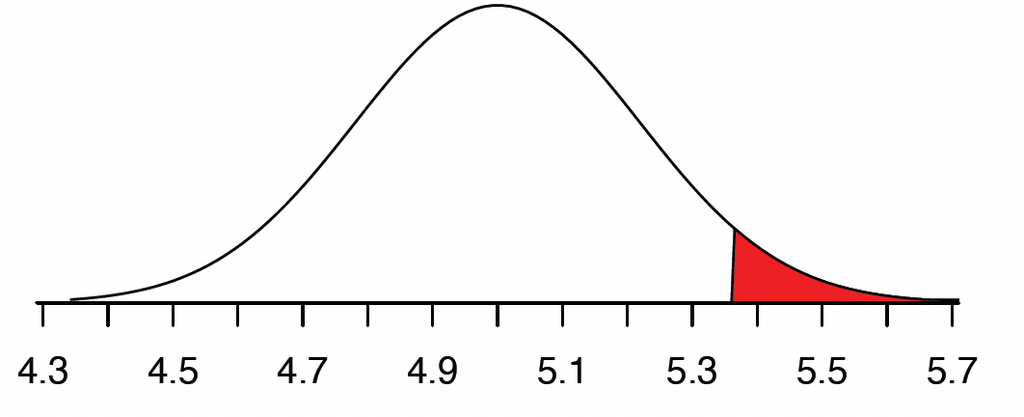

- The mean is smaller than 5 (one-sided, left):
  - H0 : μX = 5 (equivalently, H0 : μX ≥ 5 can be used).
  - H1 : μX < 5 (effect on the population).
  - Example question: did the medication decrease intelligence?

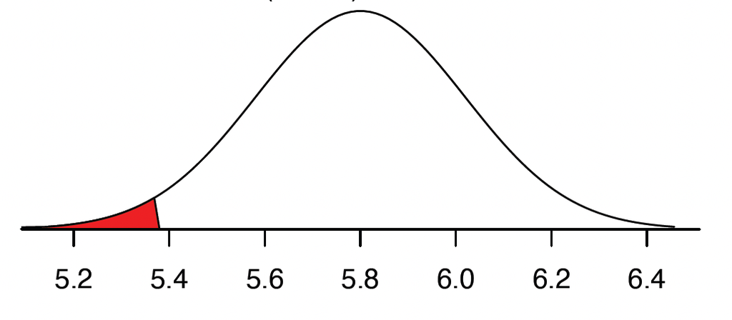

### P-Value

A p-value is the probability of obtaining results at least as extreme as the observed data, assuming the null hypothesis is true. A smaller p-value indicates stronger evidence against the null hypothesis, while a larger p-value suggests the data are consistent with the null hypothesis. A common threshold for statistical significance is a p-value of 0.05 or less, which means there is a 5% or less chance of observing the results due to random error alone.

### Error Type I and II

A **Type I error** occurs when H0 is true, but the test rejects it, leading us to incorrectly conclude that H1 is true. A small p-value does not mean that the null hypothesis is true. It is just saying it is unlikely to get results or a more extreme result when the null hypothesis is true. It could be that our sample has extreme results that show that the null hypothesis is false.

A **Type II error** occurs when H1 is true, but the test fails to reject the null hypothesis, leading us to incorrectly conclude that H0 is true. A large p-value does not mean the null hypothesis is true. It is just saying that it is likely to get such a result or a more extreme result when the null hypothesis is true. It could be that our sample has extreme results that show that the null hypothesis is true.

|  | H0 true | H0 false |
| --- | --- | --- |
| Decision to accept H0 | ✔ | Type II (β) |
| Decision to reject H0 | Type I (α) | ✔ |

## Test Types

### Z-Test Formula

We can do a z-test when the population standard deviation is known and when the sample size is greater than or equal to 30. It can only be used with one sample.

Use the formula to find the upper bounds and lower bounds for a confidence interval.

point estimate +/- zalpha / 2, (standard deviation / √sample size)

- X has a normal distribution, unknown mean, known variance
  - CI(μx)(1-α)%= x̄ ∓ zα/2 * σx / √n

Get the z score from a table.

In this test, you are only worried about one tail.

#### Example

H0: mu_{price}=4

H1: mu_{price}<4

Here, we will assume we know the standard deviation of the population, so we will use the sample standard deviation as stand-in.

```r
data.df |>
  summarize("sd" = sd(price))
```

```
         sd
1 0.9561291
```

```r
library(BSDA)
z.test(data.df$price, y=NULL, alternative="less", mu = 4, sigma.x = 0.96)
```

```
    One-sample z-Test

data:  data.df$price
z = -1.6997, p-value = 0.04459
alternative hypothesis: true mean is less than 4
95 percent confidence interval:
       NA 3.997007
sample estimates:
mean of x
 3.907323
```

```r
# sigma.x is the population standard deviation
```

The p-value (0.04) is less than alpha (0.05), so we accept the alternative hypothesis.

### T-Test Formula

Use a t-test when your population standard deviation is not given.

To calculate the t value you need a degree of freedom. Degrees of freedom is n-1.

T-tests can be used as two-tailed tests.

T-tests can be used for multiple samples.

- X has a normal distribution, unknown mean, unknown variance
  - CI(μx)(1-α)%= x̄ ∓ tn-1α/2 * sx / √n
- X has a non-normal distribution, unknown mean, unknown variance
  - CI(μx)(1-α)%= x̄ ∓ zα/2 * sx / √n
- X has a Bernoulli distribution, unknown mean, unknown variance
  - CI(px)(1-α)%= p̂ ∓ zα/2 * √p̂(1-p̂) / n

H0: mu_{price}=4

H1: mu_{price}<4

```r
t.test(data.df$price, y=NULL,alternative="less",mu=4)
```

```
    One Sample t-test

data:  data.df$price
t = -1.7066, df = 309, p-value = 0.04445
alternative hypothesis: true mean is less than 4
95 percent confidence interval:
     -Inf 3.996914
sample estimates:
mean of x
 3.907323
```

Since the p-value is less than the alpha (0.05), we accept the alternative hypothesis.

H0: mu_{price}=4

H1: mu_{price}>4

```r
t.test(data.df$price, y=NULL,alternative="greater",mu=4)
```

```
    One Sample t-test

data:  data.df$price
t = -1.7066, df = 309, p-value = 0.9556
alternative hypothesis: true mean is greater than 4
95 percent confidence interval:
 3.817731      Inf
sample estimates:
mean of x
 3.907323
```

Since the p-value is greater than the alpha (0.05), we accept the null hypothesis.

#### Two-Sided, One Sample T-Test Example

H0: mu_{price}=4

H1: mu_{price}/=4

```r
t.test(data.df$price, y=NULL,alternative="two.sided",mu=4)
```

```
    One Sample t-test

data:  data.df$price
t = -1.7066, df = 309, p-value = 0.0889
alternative hypothesis: true mean is not equal to 4
95 percent confidence interval:
 3.800469 4.014176
sample estimates:
mean of x
 3.907323
```

Since the p-value is greater than the alpha (0.05), we accept the null hypothesis.

H0: p{price>4} = 0.35

H1: p_{price>4} > 0.35

```r
prop <- ifelse(data.df$price>4, 1, 0) #Generate the Bernoulli sample with 1(meet the condition) and 0
t.test(prop, y=NULL,alternative="greater",mu=0.35)
```

```
    One Sample t-test

data:  prop
t = 2.6949, df = 309, p-value = 0.003713
alternative hypothesis: true mean is greater than 0.35
95 percent confidence interval:
 0.379399      Inf
sample estimates:
mean of x
0.4258065
```

Since the p-value is less than the alpha (0.05), we accept the alternative hypothesis.

### Chi-Square Test

Chi-square claims about population proportions

- It is a non-parametric test that is performed on categorical (nominal or ordinal) data
- Usually is best used with proportions
- degrees of freedom in this test would be the number of categories
- x2 = ∑ (f0 - fe)2 / fe

#### Example

Do Rank A and Age have a correlation?

H0: No correlation

H1: Correlation.

```r
# chi squared test
chisq.test(data.df$rankA,y=data.df$age)
```

```
    Pearson's Chi-squared test

data:  data.df$rankA and data.df$age
X-squared = 3.9292, df = 8, p-value = 0.8635
```

```r
# 1. Contingency table for RankA and age
ConTtable<-table(data.df$rankA,data.df$age)
library(lsr) # For Cramers'V
cramersV(ConTtable)
```

```
[1] 0.07960765
```

Since the p-value is greater than the alpha (0.05), we accept the null hypothesis. The cramers V is closer to zero, we know there is a weak association.

## Hypothesis testing between Populations

### The paired t-test

A paired t-test is a statistical test used to compare the means of two related groups, such as measurements taken from the same individual at different times or under two different conditions. Its purpose is to determine if there is a statistically significant difference between these paired measurements by examining the mean of the differences between the pairs.

#### Paired T-Test Example

Paired test for equal mean importance for price and value

```r
t.test(data.df$price, y=data.df$value,paired=TRUE,alternative="greater")
```

```
    Paired t-test

data:  data.df$price and data.df$value
t = -10.954, df = 309, p-value = 1
alternative hypothesis: true mean difference is greater than 0
95 percent confidence interval:
 -0.7389188        Inf
sample estimates:
mean difference
     -0.6421935
```

Since the p-value is greater than the alpha (0.05), we accept the null hypothesis.

#### Paired T-Test Example - Proportions

Paired test for differences among the proportion of consumers giving importance

```r
propP <- ifelse(data.df$price>4, 1, 0)
propV <- ifelse(data.df$value>4, 1, 0)
t.test(propV, y=propP,paired=TRUE,alternative="greater",mu=0.2)
```

```
    Paired t-test

data:  propV and propP
t = 1.4165, df = 309, p-value = 0.07882
alternative hypothesis: true mean difference is greater than 0.2
95 percent confidence interval:
 0.1925621       Inf
sample estimates:
mean difference
      0.2451613
```

Since the p-value is greater than the alpha (0.05), we accept the null hypothesis.

### Independent t-test

An independent t-test is a statistical test used to compare the means of two unrelated groups to determine if there is a significant difference between them. It is a parametric test that requires continuous data and assumes the two groups are independent and that the data within each group is normally distributed. The test determines if the observed difference between sample means is likely due to a real difference in the populations they represent.

#### Independent T-Test Example

Independent t-test for equal means of price for male and females

```r
s<-split(data.df$price,data.df$gender)#splits the variable price in two groups by gender
#first step: test for equal variances
var.test(s$male, s$female, alternative = "two.sided")
```

```
    F test to compare two variances

data:  s$male and s$female
F = 1.0826, num df = 108, denom df = 200, p-value = 0.6256
alternative hypothesis: true ratio of variances is not equal to 1
95 percent confidence interval:
 0.7829478 1.5222037
sample estimates:
ratio of variances
           1.08262
```

```r
#second step: test for differences of means
t.test(s$male, y=s$female,alternative="two.sided",mu=0,var.equal=TRUE)
```

```
    Two Sample t-test

data:  s$male and s$female
t = 1.6067, df = 308, p-value = 0.1091
alternative hypothesis: true difference in means is not equal to 0
95 percent confidence interval:
 -0.04095048  0.40549199
sample estimates:
mean of x mean of y
 4.025505  3.843234
```

Since the p-value is greater than the alpha (0.05), we accept the null hypothesis.

#### Independent T-Test Example - Proportions

```r
propP <- ifelse(data.df$price>5, 1, 0)

s<-split(propP,data.df$gender)#splits the variable price in two groups by gender
#first step: test for equal variances
var.test(s$male, s$female, alternative = "two.sided")
```

```
    F test to compare two variances

data:  s$male and s$female
F = 1.8897, num df = 108, denom df = 200, p-value = 0.0001087
alternative hypothesis: true ratio of variances is not equal to 1
95 percent confidence interval:
 1.366643 2.657020
sample estimates:
ratio of variances
          1.889722
```

Since the p-value is less than the alpha (0.05), we accept the alternative hypothesis.

### ANOVA Analysis

ANOVA (Analysis of Variance) is a statistical test for estimating how a quantitative dependent variable changes according to the levels of one or more categorical independent variables. ANOVA tests whether there is a difference in means of the groups at each level of the independent variable.

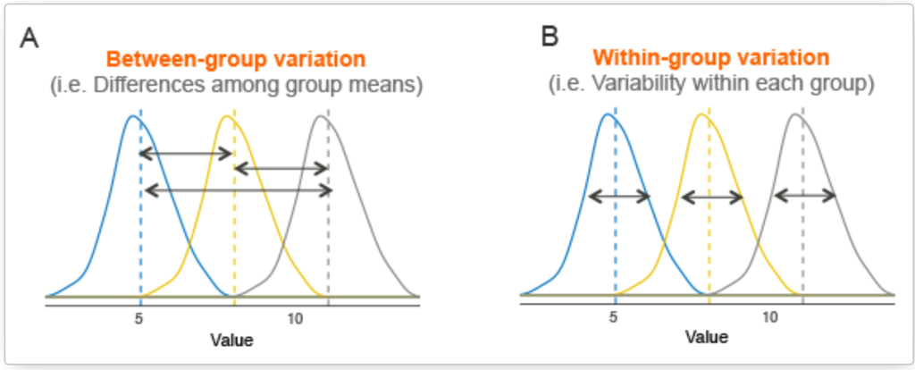

- It is used when you have three or more groups to compare, unlike a t-test which is for two groups.
- It helps test the effect of one or more independent variables (factors) on a quantitative dependent variable.
- A “two-way” or “factorial” ANOVA can examine the effects of two independent variables at once and their potential interaction.

#### One-Way ANOVA Analysis Example

```r
#boxplot of price by income
ggboxplot(data.df, x = "income", y = "value",
          color = "income", palette = c("#00AFBB", "#E7B800", "#FC4E07","orange", "green"),
          order = c("<1250", "1250-1875", "1876-2500","2501-3750",">3750","I prefer not to answer"),
          ylab = "Price", xlab = "Income")
```

[figure not shown]

```r
# Compute the analysis of variance
res.aov <- aov(value ~ income, data = data.df)
# Summary of the analysis
summary(res.aov)
```

```
             Df Sum Sq Mean Sq F value Pr(>F)
income        5    8.5   1.695   1.198   0.31
Residuals   304  430.1   1.415
```

#### Two-Way Analysis Example

Two-way analysis means there is more than one independent variable being tested.

```r
#Boxplots 'Coup' divided by gender and age.
ggboxplot(data.df, x = "age", y = "coup", color = "gender",
          palette = c("#00AFBB", "#E7B800","orange"))
```

[figure not shown]

From visual inspection, we can see that while for age range 25-34 has a smaller box plot, all still overlap. We have a wide range of means, which could imply variability.

```r
# ANOVA test
res.aov <- aov(value ~ age+gender, data = data.df)
summary(res.aov)
```

```
             Df Sum Sq Mean Sq F value Pr(>F)
age           2   10.6   5.300   3.812 0.0232 *
gender        1    2.5   2.461   1.770 0.1844
Residuals   306  425.5   1.390
---
Signif. codes:  0 '***' 0.001 '**' 0.01 '*' 0.05 '.' 0.1 ' ' 1
```

```r
data_df_grouped <- group_by(data.df,gender,age)

data_df_summary <-data_df_grouped |>
  summarise_at(vars(coup),
               list(avg=mean,stde=sd))

data_df_summary
```

```
# A tibble: 6 × 4
# Groups:   gender [2]
  gender age      avg  stde
  <chr>  <chr>  <dbl> <dbl>
1 female 25-34y  3.47  1.25
2 female 50-59y  3.65  1.48
3 female 60-60y  4.20  1.33
4 male   25-34y  2.93  1.34
5 male   50-59y  3.93  1.34
6 male   60-60y  3.66  1.66
```

Because our ANOVA analysis was significant, we will conduct a Turkey Test. It does pair-wise analysis of all possible combinations. From the results, you can see exactly where the statistics lie, showing specifically which categories of which variables have an effect.

```r
# turkey test
TukeyHSD(res.aov, which = "age")
```

```
  Tukey multiple comparisons of means
    95% family-wise confidence level

Fit: aov(formula = value ~ age + gender, data = data.df)

$age
                   diff         lwr       upr     p adj
50-59y-25-34y 0.2551760 -0.12811953 0.6384715 0.2611423
60-60y-25-34y 0.4544269  0.06547842 0.8433754 0.0172332
60-60y-50-59y 0.1992509 -0.18789469 0.5863966 0.4468868
```

```r
# turkey test plotted
plot(TukeyHSD(res.aov, "age"))
```

[figure not shown]

Plots are helpful in reports and to see direction (positive or negative) and difference.